# Analiza klientów firmy doradczej

#### Wśród bardzo zyskownych firm, odsetek firm nieobecnych w internecie wynosi zaledwie około 10%. Z kolei wśród firm które nie przynoszą bardzo dużych przychodów odsetek ten wynosi około 37%. Jest to bardzo istotna różnica, która potwierdza poprzednie wnioski mówiące że firmy obecne w sieci pozwalają przeciętnie generować większe zyski.

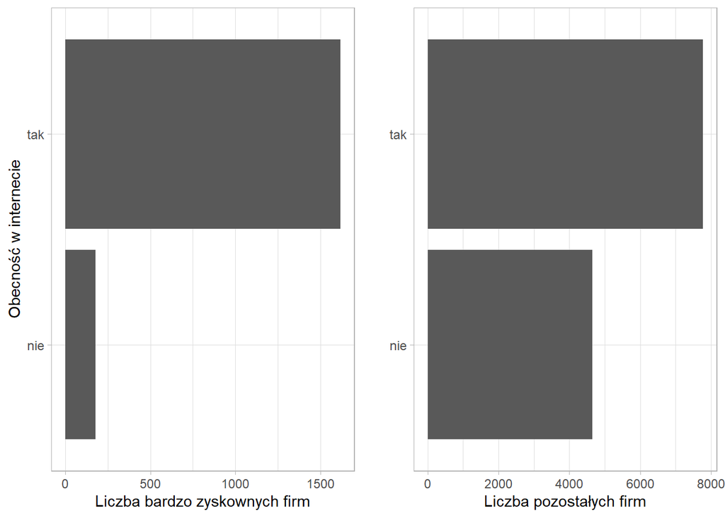

```r
make_barplots(zmienna = "obecnosc_w_internecie", xlab = "Obecność w internecie")
```

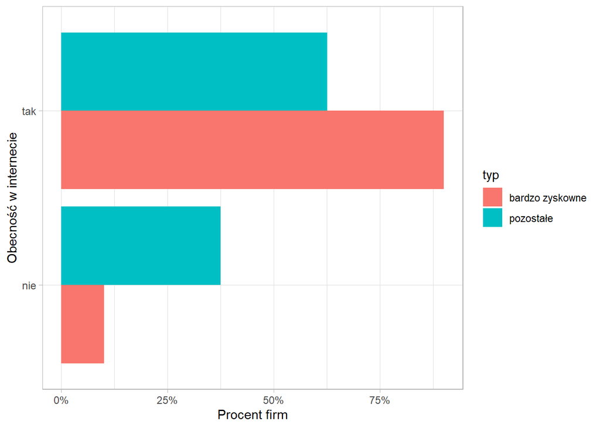

```r
make_perc_barplots(zmienna = "obecnosc_w_internecie", xlab = "Obecność w internecie")
```

#### Bardzo zyskowne firmy charakteryzują się również tym, że są aktywnymi klientami. Znaczna ich większość dokonała ostatniego zamówienia w 2020 roku (w tym roku została przeprowadzona niniejsza analiza). Niewielki odsetek stanowią firmy które dokonały ostatniego zamówienia w 2018 roku.

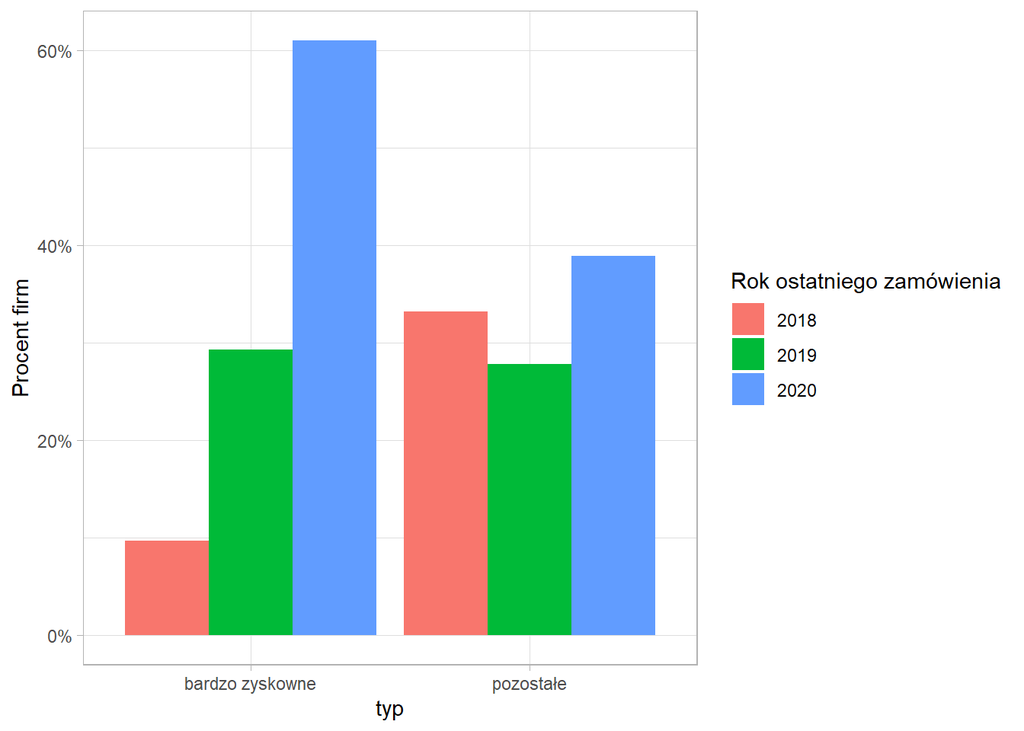

```r
firmy_comp %>% group_by(typ) %>% count(rok_ostatniego_zamowienia) %>%
  mutate(perc = n / sum(n)) %>%
  ggplot(aes(typ, perc, fill = factor(rok_ostatniego_zamowienia)))+
  geom_col(position = "dodge")+
  labs(fill = "Rok ostatniego zamówienia")+
  scale_y_continuous(labels = scales::percent_format())+
  ylab("Procent firm")
```